# Лабораторная работа №6

Основы информационной безопасности

Серёгина Ирина Андреевна

Российский университет дружбы народов, Москва, Россия

27 апреля 2024

## Цель работы

Развить навыки администрирования ОС Linux. Получить первое практическое знакомство с технологией SELinux. Проверить работу SELinx на практике совместно с веб-сервером Apache.

## Задание

1. Подготовить рабочую среду.
2. Выполнить лабораторную работу.
3. Записать вывод.

Выполнение лабораторной работы

## 1.

Для начала я обновила ПО, установила Apache с помощью команд yum update -y и yum install httpd -y. Затем вошла в систему и проверила, что SELinux работает в режиме enforcing (рис. 1).

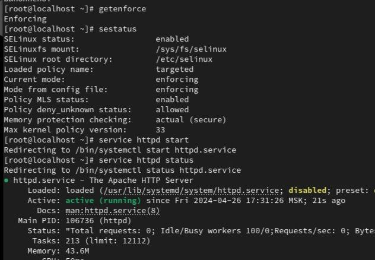

подготовка к работе

## 2.

Запустила и проверила работу веб-сервера (рис. 2).

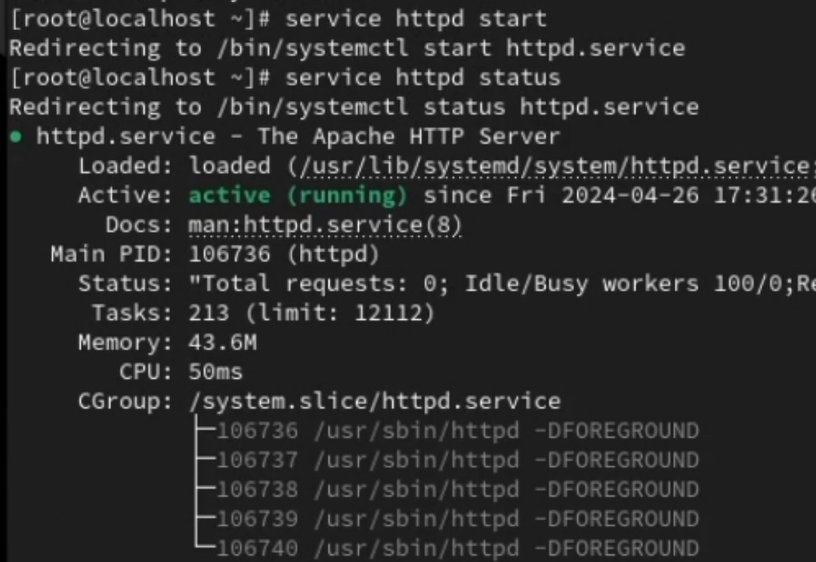

запуск работы Apache

## 3.

Узнала контекст безопасности (рис. 3).

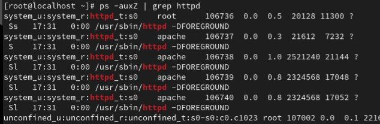

проверка контекста безопасности

## 4.

Уточнила текущее состояние переключателей SELinux для Apache (рис. 4).

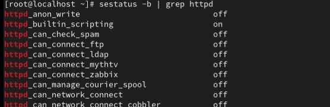

состояние переключателей

## 5.

С помощью seinfo узнала статистику по политике (рис. 5).

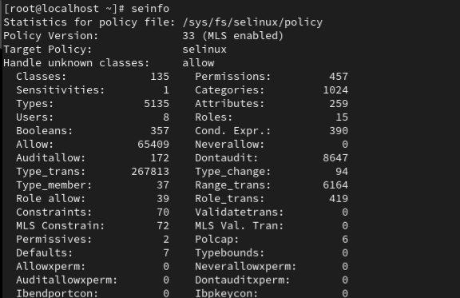

статистика по политике

## 6.

Определила тип файлов и поддиректорий директории /var/www. При определении типа файлов директории /var/www/html ничего не отображается (рис. 6).

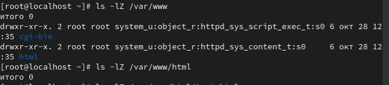

www

## 7.

Создаю файл test.html, заполняю его (рис. 7).

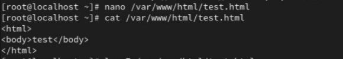

test.html

## 8.

Проверяю контекст файла (рис. 8).

[figure not shown]

контекст

## 9.

Обращаюсь к файлу через веб-сервер, его содержимое успешно отображается (рис. 9).

[figure not shown]

веб-страница файла

## 10.

Изменяю контекст файла (рис. 10).

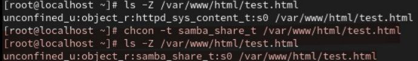

изменение контекста

## 11.

После изменения контекста доступ к файлу через веб-сервер был невозможен (рис. 11).

[figure not shown]

ошибка доступа

## 12.

В файле меняю строку Listen 80 на Listen 81, чтобы запустить веб-сервер на прослушивание TCP-порта 81 (рис. 12).

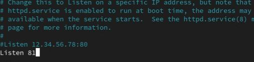

изменения в файле

## 13.

Настраиваю порт (рис. 13).

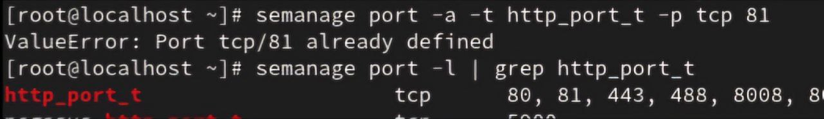

настройка порта 81

## 14.

Однако даже после этого веб-сервер на отображает файл (рис. 14).

[figure not shown]

ошибка

##15.

Изменяю контекст файла обратно, после этого страница отображает все корректно (рис. 15).

[figure not shown]

веб-страница

## 16.

Убираю изменения из конфигурационного файла, пытаюсь привязку к 81 порту, но поялвяется ошибка. Удаляю ранее созданный файл (рис. 16).

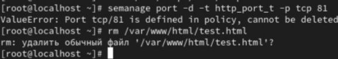

удаление файла

## Выводы

Я развила навыки администрирования ОС Linux, получила первое практическое знакомство с технологией SELinux. Проверила работу SELinx на практике совместно с веб-сервером Apache.

Спасибо за внимание!